Naomi Perez

# Motivation

One of the most useful kinds of data we can collect to benefit the safety of cities in our country is crime data. From data recorder by police forces, we can learn about what types of crime are most common in certain areas, which locations in a city are more prone to crime, what types of peope are arrested as perpetrators of crime and victims, and so much more. This allows residents of cities to better choose safe places to reside and protect themselves from crime. It also helps local government and police departments make smarter decisions in legislation on various types of crime and community resources to prevent it.

Additionally, a stay at home order has been in place for several months now, meaning that most Angelinos have been in their homes all day. This may have an impact on crime demographics and trends and we will alayze this. One could also hypothesize that because there is less outdoor activity, and more people at home guarding their belongings, there may be a decrease in certain types of crime such as burglary or vandalism. Fortunately, we have the data and tools we need to test these hypotheses.

In this tutorial, I will be analyzing and creating visualizations of a dataset describing crime reports from January 2020 to May 4th, 2020, from Los Angeles, California the second largest city in the United States. The dataset I am using can be found here https://data.lacity.org/A-Safe-City/Crime-Data-from-2020-to-Present/2nrs-mtv8. From this link, we can also find descriptions of each attribute which will be necessary to analyze the data. For example, the data uses the abbreivation Rpt Dist No which we can find from the description is a four-digit code representing the district in which the crime was reported.

# Getting Started

## Loading the Data

```r
# Importing necessary libraries
library(tidyverse)
library(rvest)
library(leaflet)
library(dplyr)
library(lubridate)

full_crimedata <- as.data.frame(read.csv("Crime_Data_from_2020_to_Present.csv"))
# We can view the first few rows in the output viewer with the head() command
head(full_crimedata)
```

```
##       DR_NO              Date.Rptd               DATE.OCC TIME.OCC AREA
## 1  10304468 01/08/2020 12:00:00 AM 01/08/2020 12:00:00 AM     2230    3
## 2 190101086 01/02/2020 12:00:00 AM 01/01/2020 12:00:00 AM      330    1
## 3 190101087 01/02/2020 12:00:00 AM 01/01/2020 12:00:00 AM      510    1
## 4 191501505 01/01/2020 12:00:00 AM 01/01/2020 12:00:00 AM     1730   15
## 5 191921269 01/01/2020 12:00:00 AM 01/01/2020 12:00:00 AM      415   19
## 6 200100501 01/02/2020 12:00:00 AM 01/01/2020 12:00:00 AM       30    1
##     AREA.NAME Rpt.Dist.No Part.1.2 Crm.Cd
## 1   Southwest         377        2    624
## 2     Central         163        2    624
## 3     Central         156        2    626
## 4 N Hollywood        1543        2    745
## 5     Mission        1998        2    740
## 6     Central         163        1    121
##                                               Crm.Cd.Desc
```

[output cut: 41 more lines]

## Tidying the Data

Our next step is to tidy the data. We already have a rectagnular dataset, meaning each attribute forms a column and each entity forms a row. So, we can start by referencing the dataset source to decide which attributes/columns we want to keep for our analysis and which columns are not significant to the results or observations we want to obtain. We can then use the pipeline syntax %>% to filter each altered dataframe into the original dataframe. We can store the columns we want to keep in a vector (list of names of the attributes) and use it in the select() function to limit our dataframe to only include the necessary columns. By limiting the number of attributes, we make loading the data and running queries much more efficient. We can also arrange it to view the dataframe by different attributes, such as the area in which the crime occurred occured as I did in this example.

```r
necessary_cols <- c("DATE.OCC", "TIME.OCC","AREA.NAME", "Crm.Cd.Desc", "Vict.Age",
                    "Vict.Sex", "Vict.Descent", "Premis.Desc", "Weapon.Desc", "LOCATION",
                    "LAT", "LON")

crimedata <- full_crimedata %>%
  select(necessary_cols) %>%
  arrange(AREA.NAME)

head(crimedata)
```

```
##                 DATE.OCC TIME.OCC   AREA.NAME
## 1 04/06/2020 12:00:00 AM     1700 77th Street
## 2 03/08/2020 12:00:00 AM     1300 77th Street
## 3 04/29/2020 12:00:00 AM     1845 77th Street
## 4 01/16/2020 12:00:00 AM     1625 77th Street
## 5 03/05/2020 12:00:00 AM     2100 77th Street
## 6 03/02/2020 12:00:00 AM     1330 77th Street
##                                Crm.Cd.Desc Vict.Age Vict.Sex Vict.Descent
## 1                 VIOLATION OF COURT ORDER       33        M            H
## 2                         VEHICLE - STOLEN        0
## 3                         VEHICLE - STOLEN        0
## 4                          BRANDISH WEAPON       69        M            B
## 5                    BURGLARY FROM VEHICLE       55        F            H
## 6 SHOPLIFTING - PETTY THEFT ($950 & UNDER)        0        X            X
##                           Premis.Desc                              Weapon.Desc
## 1                     POLICE FACILITY
## 2                              STREET
## 3                              STREET
## 4                    RECYCLING CENTER KNIFE WITH BLADE OVER 6 INCHES IN LENGTH
## 5                              STREET
## 6 DISCOUNT STORE (99 CENT,DOLLAR,ETC.
##                                  LOCATION     LAT       LON
## 1                        7600 S  BROADWAY 33.9708 -118.2783
## 2 1600 W  66TH                         ST 33.9792 -118.3046
## 3                                FLORENCE 33.9748 -118.2652
## 4                                GRAMERCY 33.9891 -118.3139
## 5 6300 S  FIGUEROA                     ST 33.9820 -118.2827
## 6 1900 W  SLAUSON                      AV 33.9921 -118.3108
```

We may also want to tidy some of the data in certain columns. For example, the attribute describing the date the crime occurred includes a time as well, but every time is represented as 12:00 am. This is probably a standardized string added to the end of the date by whichever tool was used to report the date. It is not useful for our analysis so we can alter the column using the command gsub() to not include it. More info on gsub can be found at http://www.endmemo.com/program/R/gsub.php.

We can further clean up this dataset by renaming the headers so that they are easier to interpret using the R function colnames(). There are also many empty cells in this dataset, which we will replace with the standard represention for missing data, NA.

```r
crimedata$DATE.OCC <- gsub("12:00:00 AM","", crimedata$DATE.OCC)

colnames(crimedata) <- c("date_occ", "time_occ", "area", "crime_desc", "victim_age",
                        "victim_sex", "victim_ethn", "premise", "weapon", "street_add", "lat", "lng")
# replace all missing data with NA
crimedata[crimedata==""] <- NA
head(crimedata)
```

```
##      date_occ time_occ        area                               crime_desc
## 1 04/06/2020      1700 77th Street                 VIOLATION OF COURT ORDER
## 2 03/08/2020      1300 77th Street                         VEHICLE - STOLEN
## 3 04/29/2020      1845 77th Street                         VEHICLE - STOLEN
## 4 01/16/2020      1625 77th Street                          BRANDISH WEAPON
## 5 03/05/2020      2100 77th Street                    BURGLARY FROM VEHICLE
## 6 03/02/2020      1330 77th Street SHOPLIFTING - PETTY THEFT ($950 & UNDER)
##   victim_age victim_sex victim_ethn                             premise
## 1         33          M           H                     POLICE FACILITY
## 2          0       <NA>        <NA>                              STREET
## 3          0       <NA>        <NA>                              STREET
## 4         69          M           B                    RECYCLING CENTER
## 5         55          F           H                              STREET
## 6          0          X           X DISCOUNT STORE (99 CENT,DOLLAR,ETC.
##                                     weapon
## 1                                     <NA>
## 2                                     <NA>
## 3                                     <NA>
## 4 KNIFE WITH BLADE OVER 6 INCHES IN LENGTH
## 5                                     <NA>
## 6                                     <NA>
##                                street_add     lat       lng
## 1                        7600 S  BROADWAY 33.9708 -118.2783
## 2 1600 W  66TH                         ST 33.9792 -118.3046
## 3                                FLORENCE 33.9748 -118.2652
## 4                                GRAMERCY 33.9891 -118.3139
## 5 6300 S  FIGUEROA                     ST 33.9820 -118.2827
## 6 1900 W  SLAUSON                      AV 33.9921 -118.3108
```

# Exploratory Data Analysis

Which Area in Los Angeles is Most Prone to Crime (arrests)?

Now, we can use this new dataframe to create a simple graph mapping where the most crimes occur in Los Angeles. We first have to create a pipeline that will group the data by each Los Angeles area, and then create a new variable named “num_arrests” by using the n() function to count the number of entries (arrests) for each area.

Next, we can create a plot to using the ggplot function from the tidyverse library. More on the ggplot function can be found here https://ggplot2.tidyverse.org/reference/ggplot.html. Because the labels on the x axis overlap, we have to perform some extra formatting with the theme() function.

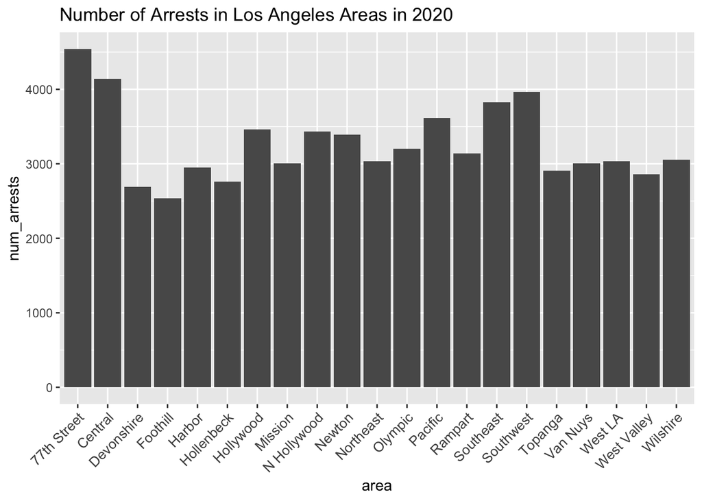

```r
crimedata_areaplot <- crimedata %>%
  group_by(area) %>%
  summarize(num_arrests = n())

plot <- ggplot(crimedata_areaplot) + geom_bar(mapping = aes(x=area, y=num_arrests),stat="identity") + ggtitle("Number of Arrests in Los Angeles Areas in 2020")

plot <- plot + theme(axis.text.x =
                   element_text(size  = 10,
                                angle = 45,
                                hjust = 1,
                                vjust = 1))
plot
```

From this plot, we can see that the 2 districts with the most arrests in 2020 are the 77th Street and Central area! This observation is integral in the LAPD’s decisions on where to allocate resources.

```r
paletteS <- colorFactor(c("pink", "purple"), domain = c("M", "F"))

la_map <- leaflet(crimedata) %>%
  addTiles() %>%
  setView(lat=34.05, lng=-118.24, zoom=11) %>%
  addCircleMarkers(
    radius = 5,
    color = ~paletteS(victim_sex),
    stroke = FALSE, fillOpacity = 0.2
  ) %>%
   addLegend("bottomleft", pal = paletteS, values = ~victim_sex, title = "Sex by Color", opacity = 1)
la_map
```

[interactive chart not shown]

How Has the Stay At Home Order Affected Crime in Los Angeles?

Next, we want to look at the number of arrests by month. This will be a good start to exploring our hypothesis that crime trends may change after the stay at home order was announced. We can do this by utilizing the date column and lubridate date/time library (https://lubridate.tidyverse.org/) to gather the month of each crime report.

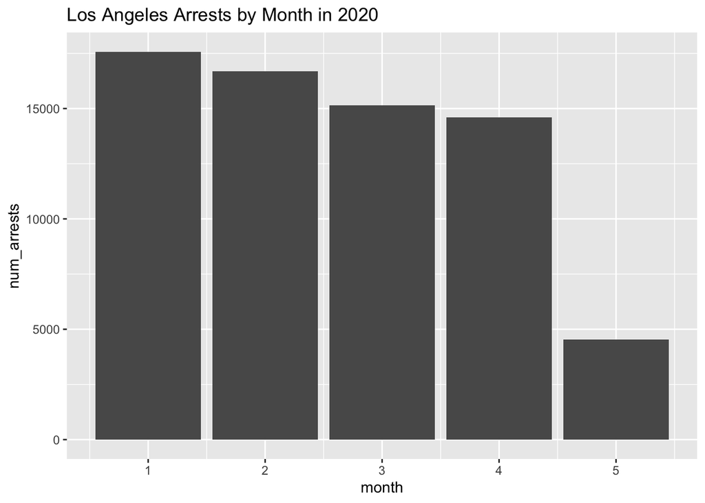

```r
#
crimedata <- crimedata %>%
  mutate(month = month(mdy(date_occ)))


# create month groups and count number of arrests for each month
crimedata_monthplot <- crimedata %>%
  group_by(month) %>%
  summarize(num_arrests = n())

# create bar
plot <- ggplot(crimedata_monthplot) + geom_bar(mapping = aes(x=month, y=num_arrests),stat="identity") +ggtitle("Los Angeles Arrests by Month in 2020")

plot
```

We can see from this plot that crime seems to have decreased over time throughout the year.

# Hypothesis Testing and Linear Regression Analysis

We can gain more accurate results by performing a linear regression analysis between time and number of arrests. We can so this using the lm function and capture the relationship between the months of 2020 labelled in ascending order, and the number of arrests.

```r
fit <- lm(formula = month~num_arrests, data = crimedata_monthplot)

broom::tidy(fit)
```

```
## # A tibble: 2 x 5
##   term         estimate std.error statistic p.value
##   <chr>           <dbl>     <dbl>     <dbl>   <dbl>
## 1 (Intercept)  6.49     1.34           4.84  0.0168
## 2 num_arrests -0.000254 0.0000924     -2.75  0.0707
```

# Conclusion